# act_report

## **Insights From an Analysis of @dog_rates Tweets**

The following insights were gathered from analysis of the cleaned master dataset:

1. Tweets tweeted on Wednesday are likely to get the least number of favorites and retweets while tweets tweeted on Tuesday are likely to get the highest number of favorites

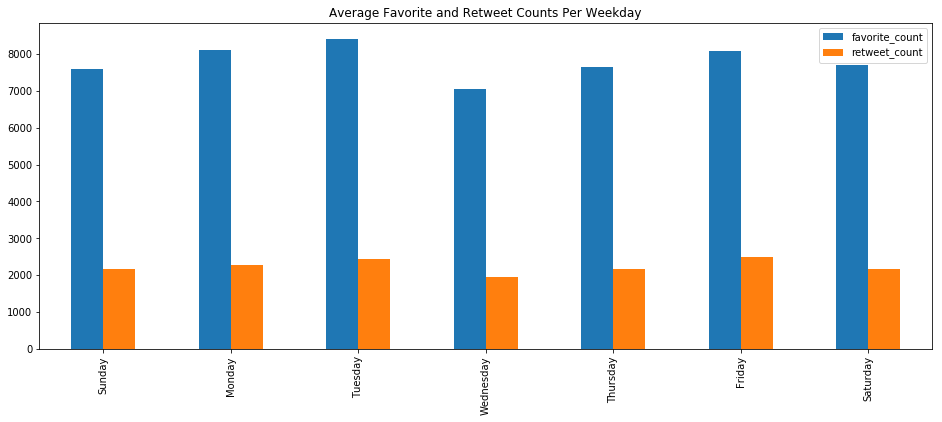

1. Tweets with [`Gofundme`](https://www.gofundme.com/)`(a crowdfunding platform)` links do not get more retweets or favorites for exposure as would be expected since WeRateDogs® is also a non-profit organization concerned with rescuing dogs and seeking treatment for sick dogs. Instead, they actually get less retweets and favorites.

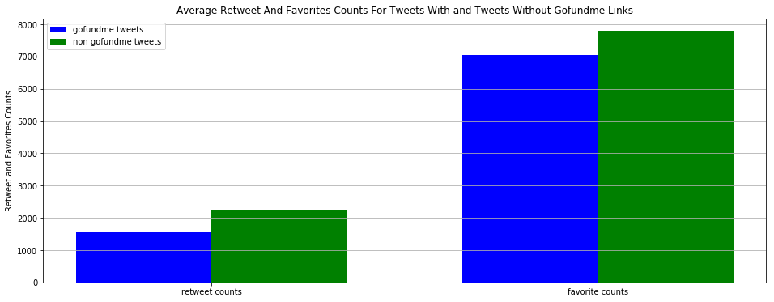

1. A tweet with a high number of favorite counts is likely to have a high number of retweets as well. On the other hand, the rating given to a dog does not directly predict the number of retweets or likes a tweet is likely to get.

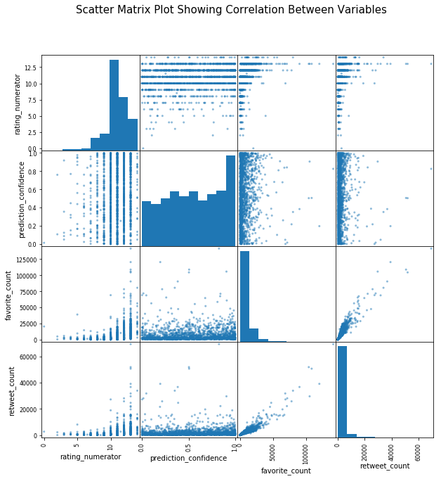

1. Reply tweets are likely to get half as many retweets and favorites as compared to original tweets directly tweeted by @dog_rates. However, the dogs on reply tweets on average get higher ratings at slightly above $\frac{12}{10}$ while the dogs on tweets directly tweeted by @dog_rates on average get a rating slightly below $\frac{11}{10}$

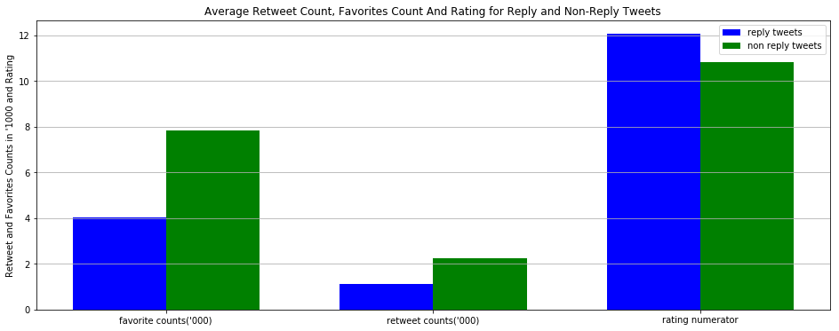

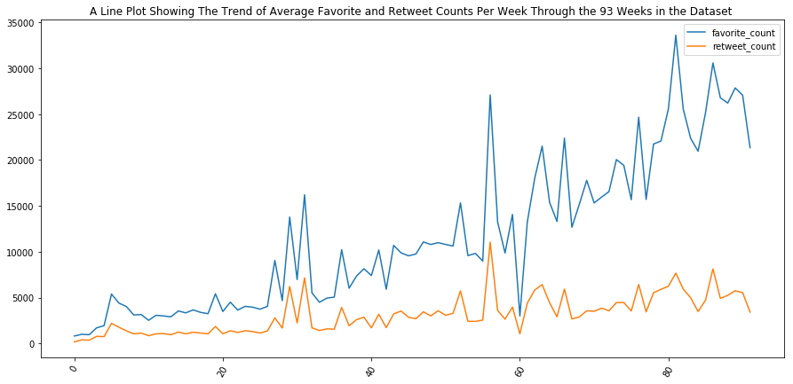

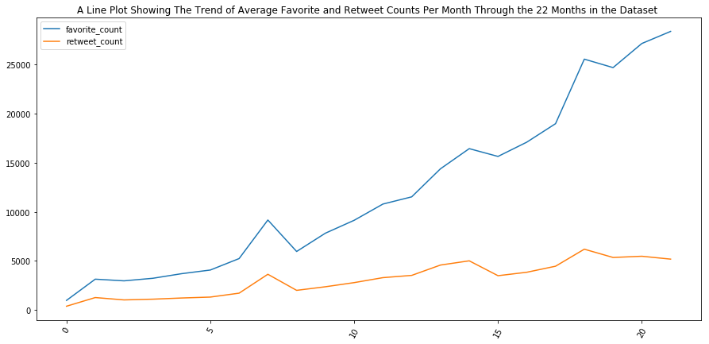

Some of the most distinctive dog breeds most confidently identified by the image prediction algorithm were the `komondor`, `keeshond`, `bull mastiff`, `brittany spaniel` and `bernesse mountain` breeds. Here is what each of the breeds looks like:

**komondor breed**

[figure not shown]

**keeshond breed**

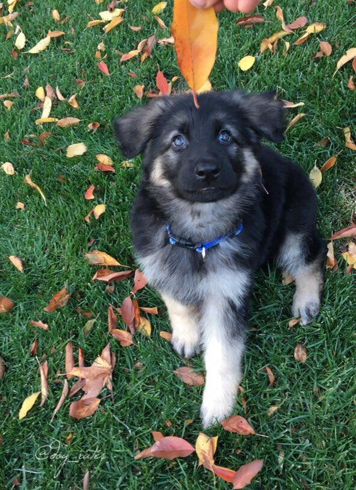

**bull mastiff breed**

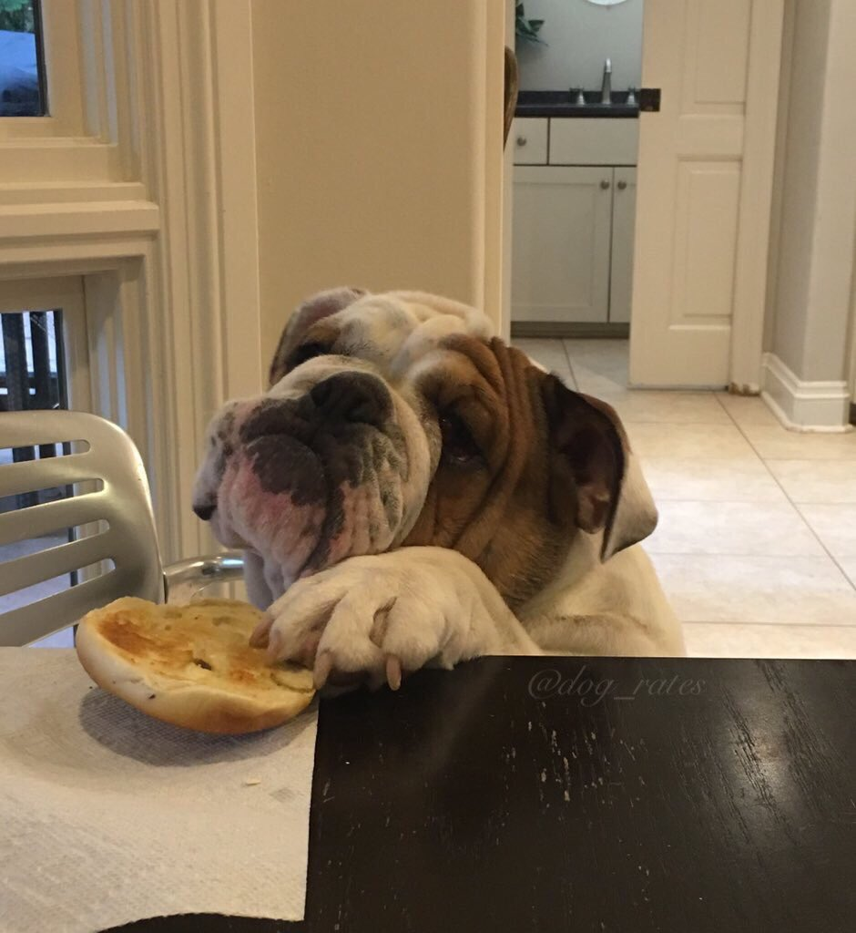

**Brittany spaniel breed**

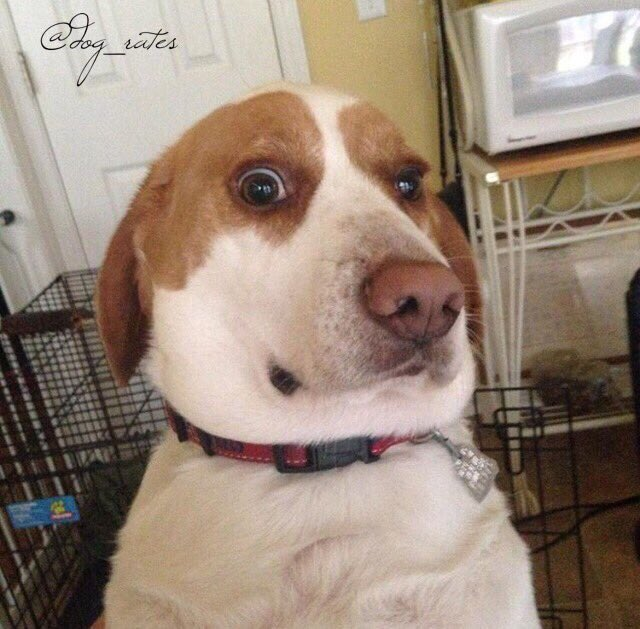

**Bernesse mountain breed**

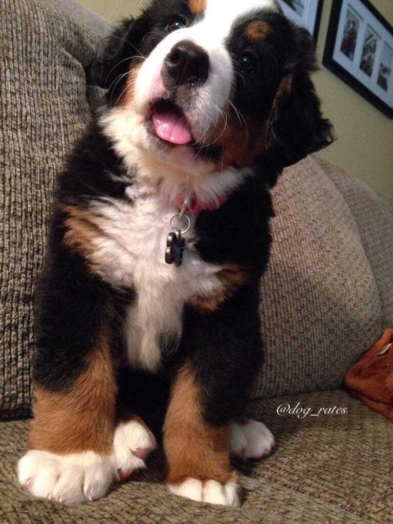